# Multivariate models

M. Rolland

2020-08-26

# Discussion points:

- is it OK we focus first on the logistic model and then once these results are OK we do the time to event model?
- wouldn’t trajectory analysis be an interesting analysis alternative?
- which data do we keep in the forward and backward analyses? all data with NA is lost
- why use weekly and not daily?
- forward: what period?
- backward: what period?
- how to fill in NAs?

```
Regarding this point, for the forward analysis I would:
- use the continuous (daily) data as it does not impact the degrees of freedom instead of weekly
- regarding NAs I see two options
- limit from week 0 to 28 (or something restrictive)
- use continuous data from week 0 to N even when gestation duration < N gw (WINDOW DATA AFTER BIRTH NOT AVAILABLE IN EMIE'S DATA BUT DOABLE)

Same for backward analysis + need to define study period.
```

- decide how to represent visually (copy Otana’s? or do a 2d plot with both lag + temp which I quite like but does not include confidence intervals)
- confirm that the model with no exposure makes sense (when comparing with litt)
- check NDVI (univariate vs multivariate??)
- check that the different relationship shapes are consistant (linear and non linear etc) and choose best AIC

# List of model covariates:

- Maternal education
- Maternal age at conception
- Active tobacco
- Maternal pre-pregnancy BMI
- Parity
- Humidity
- Season of conception
- NDVI
- Urban/rural
- cohort

# Preterms

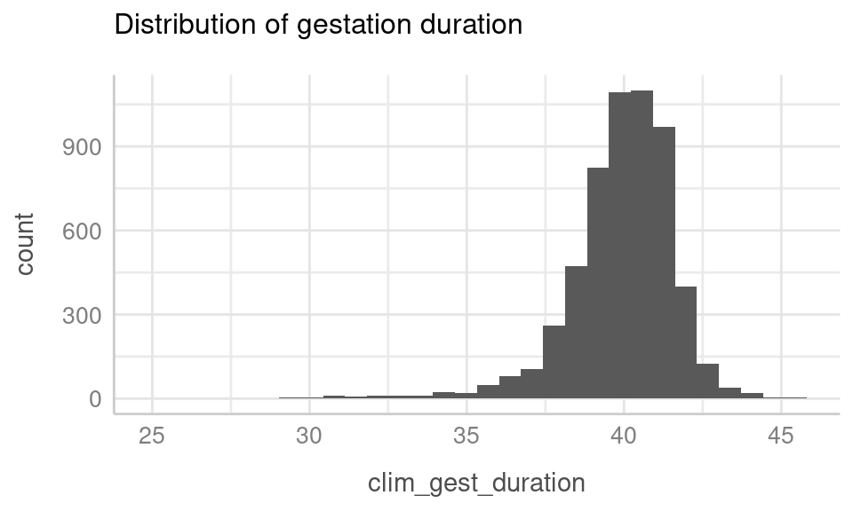

# Logistic model with no exposure

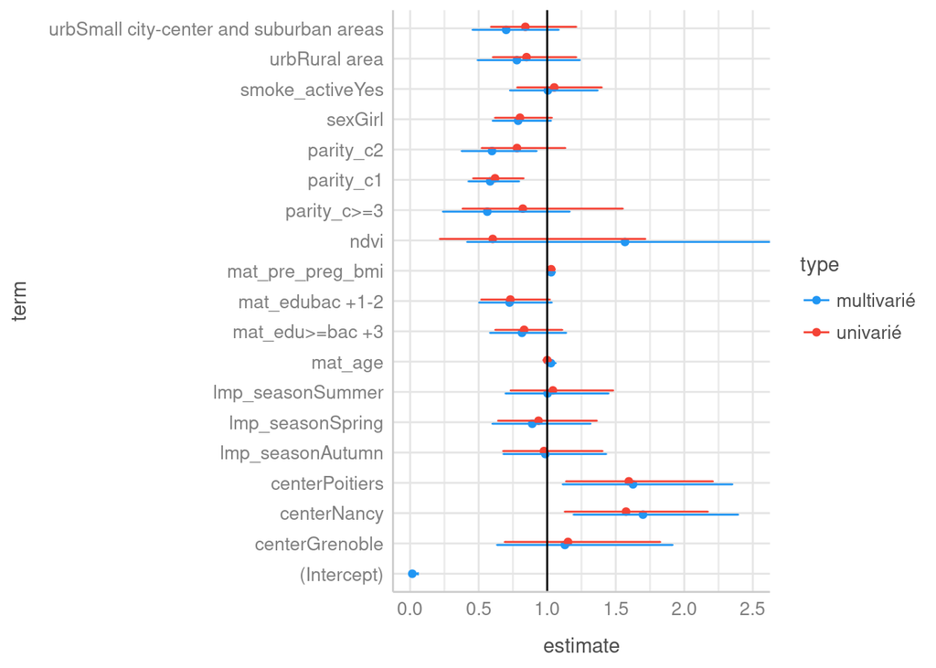

All seems consistant except for NDVI.

# Model with exposure

[Not presented for now]

DLNM vignette for our situation `vignette("dlnmExtended")`

Method notes Otana:

> - Relationships between term birthweight and meteorological exposures were initially modelled with minimal adjustment, and then modelled in a fully-adjusted framework.
> - The minimally-adjusted models were built for each exposure separately (mean temperature, standard deviation of temperature, mean humidity, and standard deviation of humidity), adjusting only for gestational age at birth.
> - Fully-adjusted models contained mean temperature, mean humidity, standard deviation of temperature, and standard deviation of humidity as simultaneous exposures, with adjustment for the aforementioned possible confounders.
> - We used distributed lag models with an exposure matrix of the first 37 gestational weeks for each meteorological exposure.
> - The exposure-response relationship was modelled linearly, and the lag-response relationship (reflecting the impact of exposure timing) was modelled with natural cubic splines.
> - Degrees of freedom were tested from 2 to 6, and chosen by minimizing the Akaike information criterion (AIC) in minimally-adjusted models for each exposure.
> - Then the selected values for degrees of freedom were used in building the fully-adjusted models, which contained all four exposures simultaneously.
> - We also checked for non-linearity of the exposure-response relationship with natural cubic splines, again testing degrees of freedom from 2 to 6 and choosing the degrees of freedom that minimized the AIC in minimal models.